# Exploring the politics of Ocean Beach Park

We explore two different explanations of support for recent urbanist ballot intiatives like Prop J and Prop K:

1. People are primarily motivated by the degree of their car-dependence.
2. People are primarily motivated by the direct inconvenience imposed by the road closure.

# Regression analysis

As a simple test of these hypotheses, we can use a linear regression to see how much of a precinct’s support for Prop K is attributable to that precinct’s support for Prop J in 2022, and how much to the direct traffic impact of the proposed changes to the Great Highway.

This assumes that, controlling for the distance of a precinct to JFK Promenade, the precinct’s support for Prop J indicates the degree of support for car-free areas in the precinct.

Futhermore, we are using the Euclidean distance from a precinct to the project as an inperfect proxy for the traffic impact felt in that precinct.

We can look at how precinct-level differential support for Prop K versus Prop J depends on the Euclidean distance of the precinct to each of the proposed closures.

OLS Regression Results

| Dep. Variable: | MeasureKYes | R-squared: | 0.844 |
| --- | --- | --- | --- |
| Model: | OLS | Adj. R-squared: | 0.843 |
| Method: | Least Squares | F-statistic: | 915.0 |
| Date: | Thu, 09 Jan 2025 | Prob (F-statistic): | 6.79e-204 |
| Time: | 10:06:28 | Log-Likelihood: | 697.50 |
| No. Observations: | 510 | AIC: | -1387. |
| Df Residuals: | 506 | BIC: | -1370. |
| Df Model: | 3 |  |  |
| Covariance Type: | nonrobust |  |  |

|  | coef | std err | t | P>\|t\| | [0.025 | 0.975] |
| --- | --- | --- | --- | --- | --- | --- |
| Intercept | -0.1394 | 0.021 | -6.781 | 0.000 | -0.180 | -0.099 |
| MeasureJYes | 0.9430 | 0.035 | 27.084 | 0.000 | 0.875 | 1.011 |
| jfk_promenade_distance | -0.1098 | 0.274 | -0.401 | 0.688 | -0.647 | 0.428 |
| great_highway_distance | 1.4080 | 0.178 | 7.903 | 0.000 | 1.058 | 1.758 |

| Omnibus: | 737.879 | Durbin-Watson: | 1.966 |
| --- | --- | --- | --- |
| Prob(Omnibus): | 0.000 | Jarque-Bera (JB): | 274002.869 |
| Skew: | -7.384 | Prob(JB): | 0.00 |
| Kurtosis: | 115.589 | Cond. No. | 137. |

Notes:  
[1] Standard Errors assume that the covariance matrix of the errors is correctly specified.

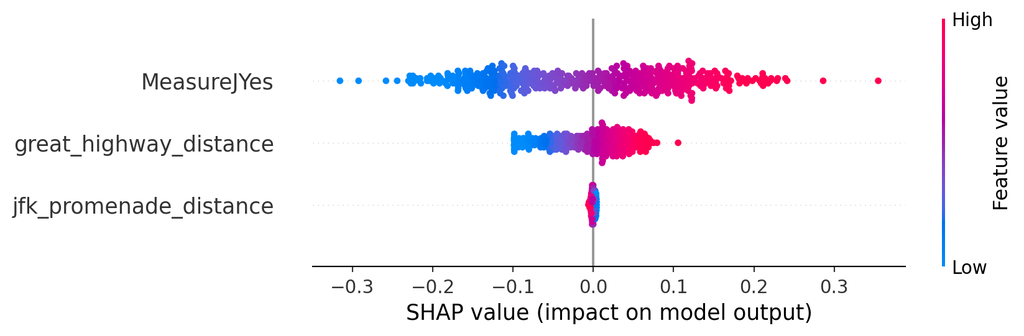

We see that there is evidence for both hypotheses, i.e. it is true both that there is evidence that people tend to support/oppose car-free projects regardless of the direct impact on their traffic patterns, and that this direct traffic impact is also a factor on precinct-level voting decisions.

Futhermore, the SHAP chart most clearly shows that Hypothesis 1 is the larger factor, explaining the majority of the variability between precincts.

# Precincts

We can dig into this further by looking at patterns across precincts for support for Prop K relative to Prop J.

First, we see again some support for Hypothesis 2, in that when fixing for the distance to JFK Promenade, support for Prop K relative to Prop J increases with the distance to the Great Highway (at least in the western part of the city).

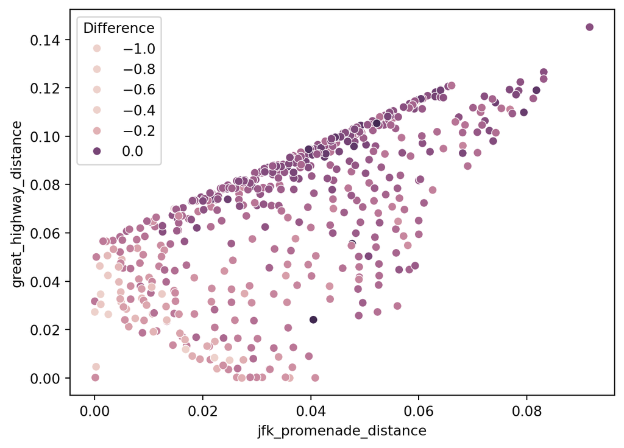

We see a similar pattern by looking at individual precincts.

[interactive chart not shown]

# Future work

Including a precinct-level covariate indicting the level of car depedence would allow us to evaluate Hypothesis 1 more directly. Perhaps we could pull something from census data?

Also, this analysis is limited by using Euclidean distance to Great Highway as a proxy for the impact on an individual. It would be better to use a more direct measure of the impact based on e.g. origin-destination data of car trips.

Also, looking at individual voter results would give us much more signal on the actual drivers of voter decisions, rather than relying on precinct-level correlations.